# Unemployment

Doesn’t this hit too close to home… Here’s the data.

```r
library(tidyverse)

emp <- readr::read_csv('https://raw.githubusercontent.com/rfordatascience/tidytuesday/master/data/2021/2021-02-23/employed.csv')

earn <- readr::read_csv('https://raw.githubusercontent.com/rfordatascience/tidytuesday/master/data/2021/2021-02-23/earn.csv')
```

```r
skimr::skim(emp)
```

```
-- Data Summary ------------------------
                           Values
Name                       emp
Number of rows             8184
Number of columns          7
_______________________
Column type frequency:
  character                4
  numeric                  3
________________________
Group variables            None

-- Variable type: character ----------------------------------------------------
# A tibble: 4 x 8
  skim_variable    n_missing complete_rate   min   max empty n_unique whitespace
* <chr>                <int>         <dbl> <int> <int> <int>    <int>      <int>
1 industry               330         0.960     3    46     0       25          0
2 major_occupation         0         1        19    60     0        5          0
3 minor_occupation         0         1        22    59     0       12          0
4 race_gender              0         1         3    25     0        6          0

-- Variable type: numeric ------------------------------------------------------
# A tibble: 3 x 11
  skim_variable  n_missing complete_rate     mean         sd    p0    p25
* <chr>              <int>         <dbl>    <dbl>      <dbl> <dbl>  <dbl>
1 industry_total       660         0.919 5077105. 6056216.   18000 767250
2 employ_n             660         0.919  461552. 1267564.       0   9000
3 year                   0         1        2018.       1.71  2015   2016
       p50     p75     p100 hist
*    <dbl>   <dbl>    <dbl> <chr>
1 2484000  7643000 35894000 ▇▂▁▁▁
2   65000   373000 20263000 ▇▁▁▁▁
3    2018.    2019     2020 ▇▃▃▃▃
```

The first dataset is about employment. It seems there are two variables of interest: `employ_n` and `industry_total`; the first is the number of employed persons and the second is the total number of persons in that industry. Grouping variables are: `industry`, `major_occupation`, `minor_occupation`, and `race_gender`. It’s broken down by year. There are missing values for industry, industry total, and number of employed persons (96%, 92%, and 92% complete respectively). The industry total is far greater than the `employ_n` variable; `employ_n` is 9% of `industry_total` at the mean, which aligns more with unemployment numbers rather than employement numbers. Ah, but `industry` total might not be broken down by major and minor occupation. The values might repeat. Years covered are 2015 to 2020.

```r
skimr::skim(earn)
```

```
-- Data Summary ------------------------
                           Values
Name                       earn
Number of rows             4224
Number of columns          8
_______________________
Column type frequency:
  character                4
  numeric                  4
________________________
Group variables            None

-- Variable type: character ----------------------------------------------------
# A tibble: 4 x 8
  skim_variable n_missing complete_rate   min   max empty n_unique whitespace
* <chr>             <int>         <dbl> <int> <int> <int>    <int>      <int>
1 sex                   0             1     3    10     0        3          0
2 race                  0             1     5    25     0        4          0
3 ethnic_origin         0             1    11    18     0        2          0
4 age                   0             1    14    17     0       12          0

-- Variable type: numeric ------------------------------------------------------
# A tibble: 4 x 11
  skim_variable      n_missing complete_rate       mean          sd     p0
* <chr>                  <int>         <dbl>      <dbl>       <dbl>  <dbl>
1 year                       0             1     2015          3.16   2010
2 quarter                    0             1        2.5        1.12      1
3 n_persons                  0             1 16268338.  22421841.   103000
4 median_weekly_earn         0             1      762.       217.      318
         p25       p50         p75      p100 hist
*      <dbl>     <dbl>       <dbl>     <dbl> <chr>
1    2012       2015       2018         2020 ▇▅▅▅▅
2       1.75       2.5        3.25         4 ▇▇▁▇▇
3 2614000    7441000   17555250    118358000 ▇▁▁▁▁
4     605        755        911         1709 ▅▇▅▁▁
```

The second dataset is on weekly median earnings and number of persons employed based on `sex`, `race`, `ethnic_origin`, and `age`. It’s broken out by year and quarter. This data is complete with no missing values. Years covered are 2010 to 2020.

I have a vague idea for a graphic based on old blank VHS tapes. See `vhs_tapes.svg` in my `R` folder (not on GitHub). It will require 3-4 bars of comparable heights. There are four values for race, so I could compare earnings. Let’s see.

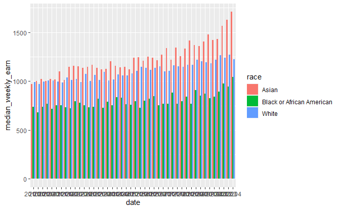

I’ll only use the averaged 2020 data.

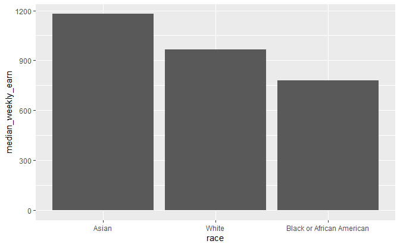

Now it’s just a matter of making the polygons. The question is whether I should have mitre cuts for edges or 90-degree angles? If it’s angles, I only have to use segments. If not, I have to create polygons for each bar where the hypotenuse is mapped to median weekly earnings. I’ll make both and see which I like better.